# PSYCH 490.007: Exercise 04 – PSYCH 490.007

Making figures with *ggplot*

Author

Rick Gilmore

Published

October 28, 2026

## About

This page documents Rick Gilmore’s work related to completing Exercise 04 for PSYCH 490.007 in Fall 2026.

The assignment involves choosing an existing dataset and making at least three (3) visualizations using the *ggplot2* package. For each figure, I am to write a short summary of the question I intend to ask with the figure, and how the visualization I generate answers or doesn’t answer the question. If my figure doesn’t clearly answer the question, then I should explain how the figure might be improved or clarified to do so. This critique could include a suggestion to use a different type of figure.

## Setup

```r
library(ggplot2)
library(nflreadr)
```

## Explore datasets

```r
data()
```

I chose to use the *schedules* dataset from the *nflreadr* package.

## Load dataset

```r
nfl_scheds <- load_schedules() # nflreadr
```

Using `summary(nfl_scheds)`, I discover that the dataset has the following variables:

```r
summary(nfl_scheds)
```

```
      game_id         season         game_type         week
 Length   :7548   Min.   :1999   Length   :7548   Min.   : 1.000
 N.unique :7548   1st Qu.:2006   N.unique :   5   1st Qu.: 5.000
 N.blank  :   0   Median :2013   N.blank  :   0   Median :10.000
 Min.nchar:  13   Mean   :2013   Min.nchar:   2   Mean   : 9.597
 Max.nchar:  15   3rd Qu.:2020   Max.nchar:   3   3rd Qu.:14.000
                  Max.   :2026                    Max.   :22.000

      gameday          weekday          gametime        away_team
 Length   :7548   Length   :7548   Length   :7548   Length   :7548
 N.unique :1479   N.unique :   7   N.unique :  57   N.unique :  35
 N.blank  :   0   N.blank  :   0   N.blank  :   0   N.blank  :   0
 Min.nchar:  10   Min.nchar:   6   Min.nchar:   5   Min.nchar:   2
 Max.nchar:  10   Max.nchar:   9   Max.nchar:   5   Max.nchar:   3
                                   NAs      : 259

   away_score        home_team      home_score         location
 Min.   : 0.00   Length   :7548   Min.   : 0.00   Length   :7548
 1st Qu.:14.00   N.unique :  35   1st Qu.:16.00   N.unique :   2
 Median :20.00   N.blank  :   0   Median :23.00   N.blank  :   0
 Mean   :20.99   Min.nchar:   2   Mean   :23.29   Min.nchar:   4
 3rd Qu.:27.00   Max.nchar:   3   3rd Qu.:30.00   Max.nchar:   7
 Max.   :59.00                    Max.   :70.00
 NAs    :165                      NAs    :165
     result            total           overtime          old_game_id
 Min.   :-49.000   Min.   :  3.00   Min.   :0.00000   Length   :7548
 1st Qu.: -7.000   1st Qu.: 34.00   1st Qu.:0.00000   N.unique :7540
 Median :  3.000   Median : 44.00   Median :0.00000   N.blank  :   0
 Mean   :  2.303   Mean   : 44.28   Mean   :0.06122   Min.nchar:  10
 3rd Qu.: 11.000   3rd Qu.: 53.00   3rd Qu.:0.00000   Max.nchar:  10
 Max.   : 59.000   Max.   :106.00   Max.   :1.00000
 NAs    :165       NAs    :165      NAs    :165
      gsis             nfl_detail_id         pfr            pff
 Min.   :5.880e+02   Length   :7548   Length   :7548   Min.   :  731
 1st Qu.:2.886e+04   N.unique : 272   N.unique :7548   1st Qu.: 2154
 Median :5.575e+04   N.blank  :   0   N.blank  :   0   Median : 3597
 Mean   :3.152e+05   Min.nchar:  36   Min.nchar:  12   Mean   : 7982
 3rd Qu.:5.812e+04   Max.nchar:  36   Max.nchar:  12   3rd Qu.:13782
 Max.   :1.999e+09   NAs      :7276                    Max.   :30712
 NAs    :165                                           NAs    :2893
```

[output cut: 39 more lines]

```
 NAs    :2297
    home_qb_name      away_coach       home_coach        referee
 Length   :7548   Length   :7548   Length   :7548   Length   :7548
 N.unique : 323   N.unique : 177   N.unique : 177   N.unique :  91
 N.blank  :   0   N.blank  :   0   N.blank  :   0   N.blank  :   0
 Min.nchar:   6   Min.nchar:   7   Min.nchar:   7   Min.nchar:   8
 Max.nchar:  24   Max.nchar:  20   Max.nchar:  20   Max.nchar:  16
 NAs      : 151                                     NAs      : 208

     stadium_id        stadium
 Length   :7548   Length   :7548
 N.unique :  67   N.unique : 111
 N.blank  :   0   N.blank  :   0
 Min.nchar:   5   Min.nchar:   8
 Max.nchar:   5   Max.nchar:  35
```

## Make figures

### Figure 1

This figure shows a violin plot of home team scores. It should show whether there is a modal (most common) value.

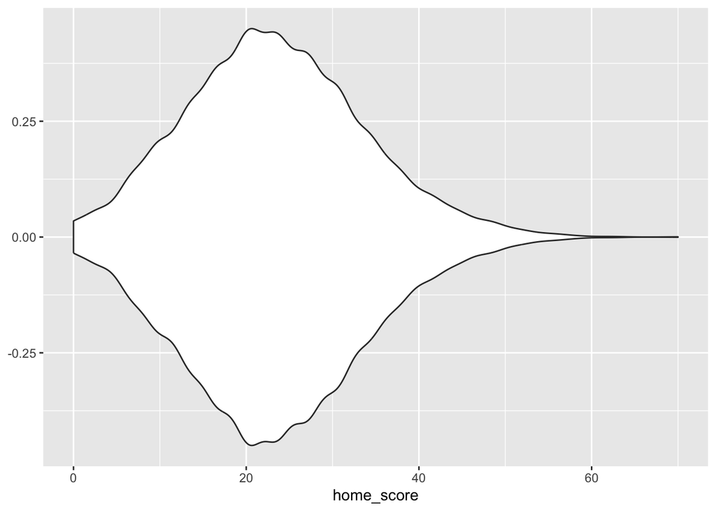

Figure 1

```r
nfl_scheds |>
  ggplot() +
  aes(x = home_score) +
  geom_violin()
```

The violin shape is widest between 20 and about 25, indicating that scores in this range are the most common.

I could confirm this with the following R code:

```r
with(nfl_scheds, summary(home_score))
```

```
   Min. 1st Qu.  Median    Mean 3rd Qu.    Max.     NAs
   0.00   16.00   23.00   23.29   30.00   70.00     165
```

Sure enough, the mean is 23.3 and the median 23.

### Figure 2

For Figure 2, I decided to try to plot my own version of a figure I linked to in Exercise 02.

Here is the figure from Exercise 02:

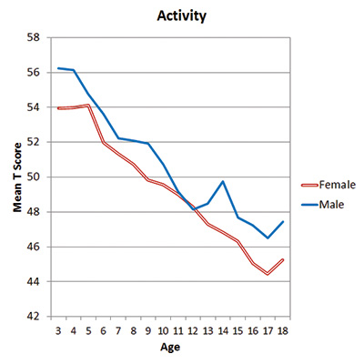

Figure 2: Figure 1 from https://www.psychologicalscience.org/redesign/wp-content/uploads/2015/12/TCD_fig_1.jpg

Here is the figure I made:

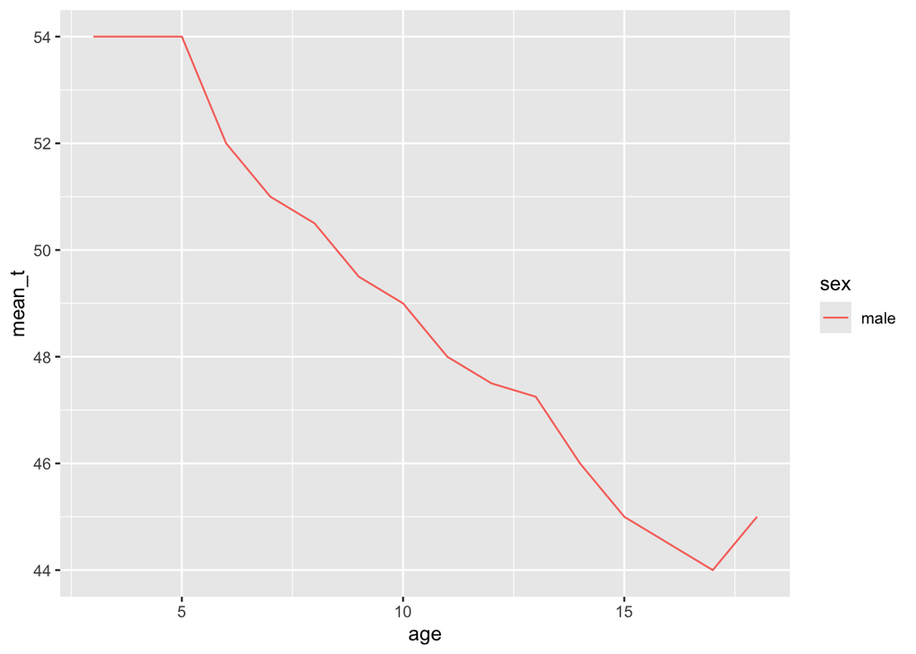

Figure 3: Regenerating Figure 1 from https://www.psychologicalscience.org/redesign/wp-content/uploads/2015/12/TCD_fig_1.jpg

```r
age <- seq(from=3, to = 18)
mean_t <- c(54, 54, 54, 52, 51, 50.5, 49.5, 49, 48, 47.5, 47.25, 46, 45, 44.5, 44, 45)
sex = rep("male", length(age))

activity <- data.frame(age, mean_t)

activity |>
  ggplot() +
  aes(x = age, y = mean_t, color = sex) +
  geom_line()
```